# 2017_04_Homework_python

**Introduction to Machine Learning**  
**Homework 4**  
**Due Tuesday, 11/7/2017, 10:30 AM**

|  | by Prof. Seungchul Lee iSystems Design Lab UNIST http://isystems.unist.ac.kr/ |
| --- | --- |

**Please!**

- Please email your .ipynb file to (`hojin12312@gmail.com`) for your code score.
- When you send an e-mail, write down [Machine Learning HW4] on the title
- And please write your NAME on your .ipynb files. ex) 이광호_20141404_HW4.ipynb, or Kwangho_20141404_HW4.ipynb
- Your printed code will not be scored.

# Problem 1

### [Monty Hall Problem](http://en.wikipedia.org/wiki/Monty_Hall_problem) with Monte Carlo Simulations

Suppose you’re on a game show, and you’re given the choice of three doors: Behind one door is a car; behind the others, goats. You pick a door, say No. 1, and the host, who knows what’s behind the doors, opens another door, say No. 3, which has a goat. He then says to you, “Do you want to pick door No. 2?” Is it to your advantage to switch your choice?

```python
%%html
<center><iframe width="560" height="315" src="https://www.youtube.com/embed/HH-676dOCFs?rel=0"
frameborder="0" allowfullscreen></iframe></center>
```

[video not shown]

Solve this problem with monte carlo simulation and print out the winning rate about 'Staying' and 'Switching'

You can utilize the below functions

```python
import numpy as np
from random import shuffle, choice
```

`np.random.randint(x)` : return random integer from 0 to (x-1)

```python
np.random.randint(3)
```

```
2
```

`shuffle(list)` : randomly shuffle the positioin of elements in list

```python
doors = ['car', 'goat', 'goat']
print(doors)
shuffle(doors)
print(doors)
```

```
['car', 'goat', 'goat']
['goat', 'car', 'goat']
```

`choice(list)`: choice random element in list

```python
choice([0, 1, 2])
```

```
2
```

### Sample output

```
Start simulation ...

Winning rate
Staying: 33.396100%
Switching: 66.603900%
```

# Problem 2

Solove the problem with Fisher Discriminant Analysis and plot the projection line.

```python
import numpy as np
import random
import matplotlib.pyplot as plt
```

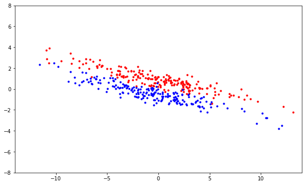

```python
n0 = 200
n1 = 200

sigma = [[19, -4],
         [-4, 1]]

x0 = np.random.multivariate_normal([0.7,0.7], sigma, n0)        # data in class 0
x1 = np.random.multivariate_normal([-0.5,-0.5], sigma, n1)      # data in class 0

x0 = np.asmatrix(x0)
x1 = np.asmatrix(x1)

plt.figure(figsize = (10, 6))
plt.plot(x0[:,0],x0[:,1],'r.')
plt.plot(x1[:,0],x1[:,1],'b.')
plt.ylim([-8, 8])
plt.xlim([-14, 14])
plt.show()
```

# Problem 3

Solove the above problem with PCA and plot the projection line. In the case of PCA, you do not need to consider labels.(*i.e.* data class)

# Probelm 4

In this problem, you have to reduce the dimension of 5-dimensional data. Plot the ratio of each eigen values and think about how many principal components should be remained. In other words, how do we decide the number of features of the data to be remained?

```python
import numpy as np
import random
import matplotlib.pyplot as plt
from scipy import random, linalg

A = random.rand(5,5)
A = np.asmatrix(A)
sigma = A.T*A

X = np.random.multivariate_normal([0.,0.,0.,0.,0.],sigma, 1000)
print(X.shape)
print(X)
```

```
(1000, 5)
[[ 0.24207134  0.14660988  0.24841063  0.51417073  0.44682695]
 [-1.43156619 -1.40909108 -1.18491061 -0.85440151 -0.82483584]
 [ 0.3140949   0.63623065  0.34537027 -0.14488548 -0.21169422]
 ...,
 [ 0.33484325  2.76917064  1.54421083  0.38865301  0.74029276]
 [-0.47019822  0.00887582  0.09020657 -0.55144115 -0.6616407 ]
 [-0.26185023 -1.01739948 -0.52039481 -0.97111141 -0.38813665]]
```

Expected output (one of examples)

[figure not shown]